# HCL-Based Color Scales for ggplot2

## Overview

All HCL-based color palettes in the *colorspace* package (Ihaka et al. 2018) are also provided as discrete and/or continuous color scales for the use with the *ggplot2* package (Wickham 2016).

The scales are called via the scheme `scale_<aesthetic>_<datatype>_<colorscale>()`, where `<aesthetic>` is the name of the aesthetic (`fill`, `color`, `colour`), `<datatype>` is the type of the variable plotted (`discrete` or `continuous`) and `<colorscale>` sets the type of the color scale used (`qualitative`, `sequential`, `diverging`, `divergingx`). We now provide a few examples of these scales.

## Using the scales in ggplot2

A discrete qualitative scale applied to a fill aesthetic corresponds to the function `scale_fill_discrete_qualitative()`:

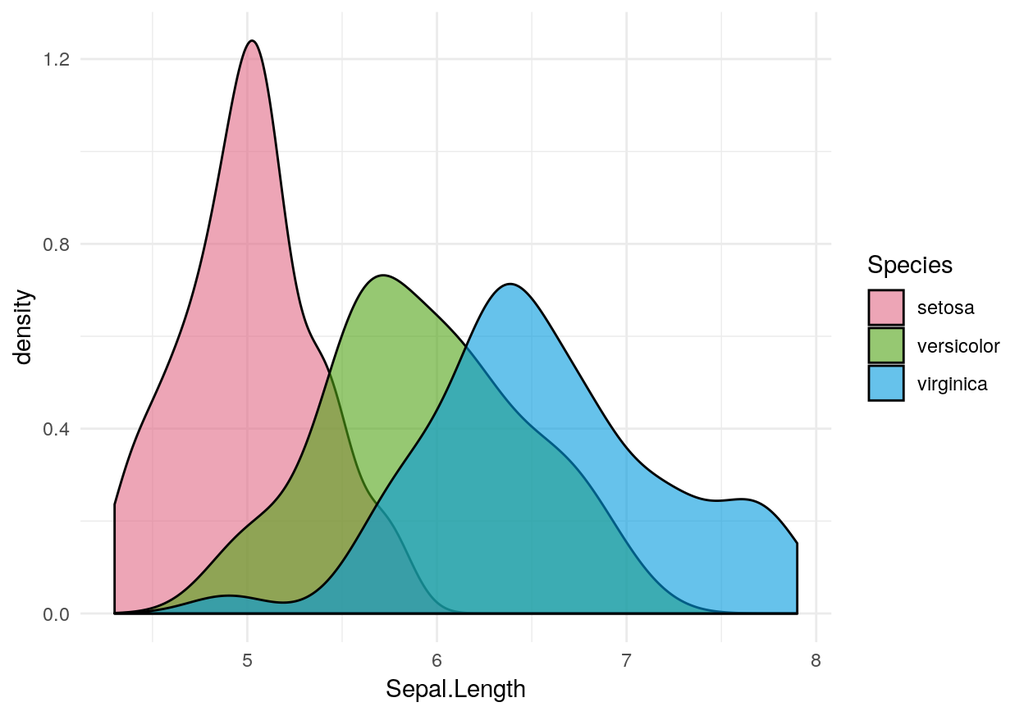

```r
ggplot(iris, aes(x = Sepal.Length, fill = Species)) + geom_density(alpha = 0.6) +
  scale_fill_discrete_qualitative()
```

A continuous sequential scale applied to a color aesthetic corresponds to the function `scale_color_continuous_sequential()`:

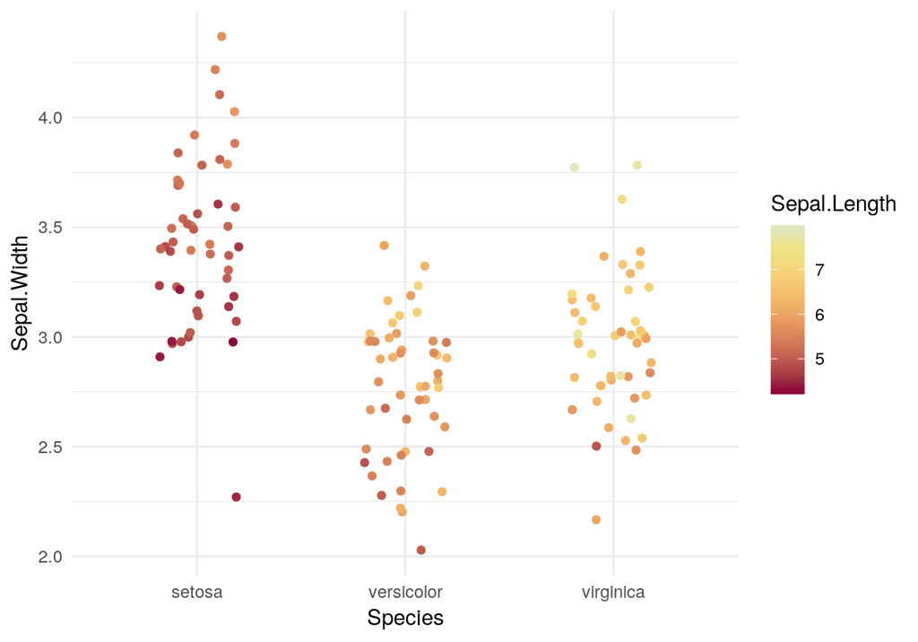

```r
ggplot(iris, aes(x = Species, y = Sepal.Width, color = Sepal.Length)) + geom_jitter(width = 0.2) +
  scale_color_continuous_sequential(palette = "Heat")
```

A continuous sequential scale applied to a fill aesthetic corresponds to the function `scale_fill_continuous_sequential()`:

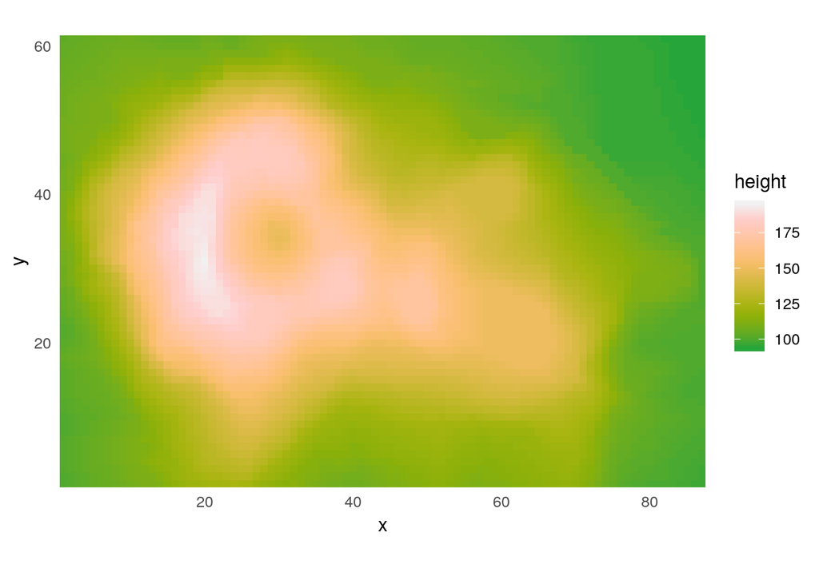

```r
nx = 87
ny = 61
df <- data.frame(height = c(volcano), x = rep(1:nx, ny), y = rep(1:ny, each = nx))
ggplot(df, aes(x, y, fill = height)) +
  geom_raster() +
  coord_fixed(expand = FALSE) +
  scale_fill_continuous_sequential(palette = "Terrain")
```

A continuous diverging scale applied to a fill aesthetic corresponds to the function `scale_fill_continuous_diverging()`:

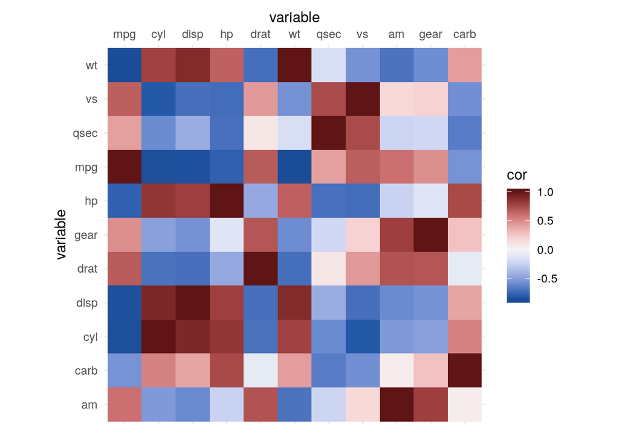

```r
cm <- cor(mtcars)
df_wide <- as.data.frame(cm)
df_long <- stack(df_wide)
names(df_long) <- c("cor", "var1")
df_long <- cbind(df_long, var2 = rep(rownames(cm), length(rownames(cm))))
ggplot(df_long, aes(var1, var2, fill=cor)) +
  geom_tile() +
  coord_fixed() +
  ylab("variable") +
  scale_x_discrete(position = "top", name = "variable") +
  scale_fill_continuous_diverging("Blue-Red 3")
```

## Customizing the scales

All scale functions accept a `palette` argument which allows you to pick a specific color palette out of a selection of different options. All available palettes are listed at the end of this document. For example, we could use the “Harmonic” palette when we need a qualitative color scale:

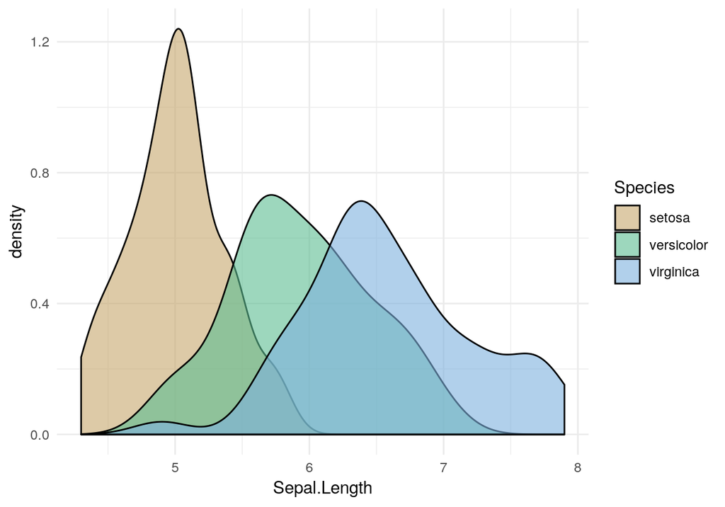

```r
ggplot(iris, aes(x = Sepal.Length, fill = Species)) + geom_density(alpha = 0.6) +
  scale_fill_discrete_qualitative(palette = "Harmonic")
```

The color palettes are calculated on the fly depending on the number of different colors needed. But sometimes, it may be desireable to pick specific colors out of a larger set, e.g. when we’re making two plots where one contains a subset of the data of the other, or when the default order of colors is not ideal. Therefore, all discrete scales provide parameters `nmax` to set the total number of colors requested and `order` (a vector of integers) to reorder the color palette.

Applied to the previous plot, we could for example do the following:

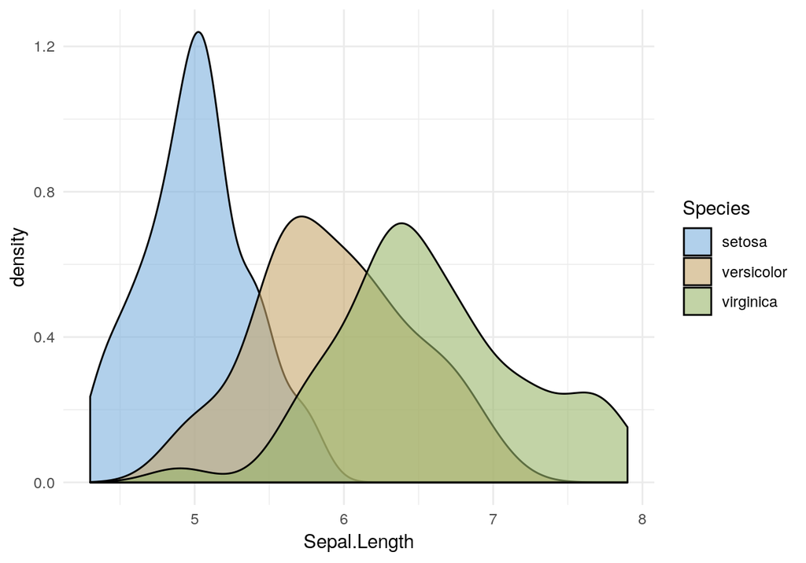

```r
ggplot(iris, aes(x = Sepal.Length, fill = Species)) + geom_density(alpha = 0.6) +
  scale_fill_discrete_qualitative(palette = "Harmonic", nmax = 5, order = c(5, 1, 2))
```

The `nmax` option is also convenient to remove some colors from a scale that may not be appropriate for the plot. For example, the `scale_color_brewer()` scale that comes with ggplot tends to produce points that are too light:

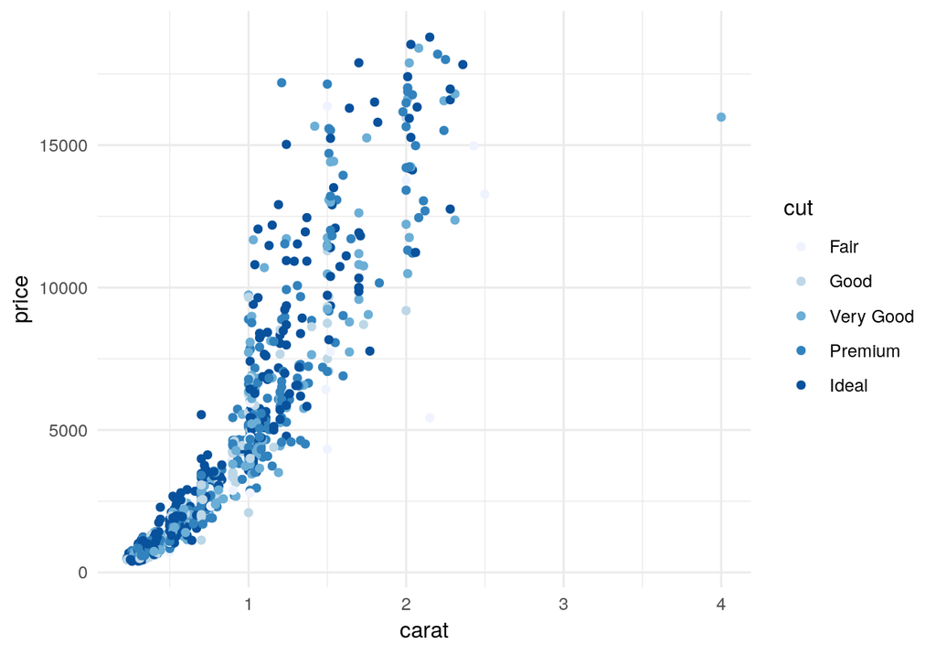

```r
dsamp <- diamonds[sample(nrow(diamonds), 1000), ]
gg <- ggplot(dsamp, aes(carat, price, color = cut)) + geom_point()
gg + scale_color_brewer(palette = "Blues")
```

Similar problems can arise with the HCL palettes, but there we have the option of creating additional colors that we then don’t use:

[figure not shown]

```r
gg + scale_color_discrete_sequential(palette = "Blues", nmax = 6, order = 5:1)
```

All scales are defined via sets of hue (H), chroma (C), and luminance (L) values. For example, the qualitative scales vary hue from a start value to an end value while keeping chroma and luminance fixed. Similarly, single-hue sequential scales vary chroma and luminance while keeping the hue fixed. We can override these settings by specifying the corresponding H, C, or L values in addition to the palette name. As an example, consider the following plot:

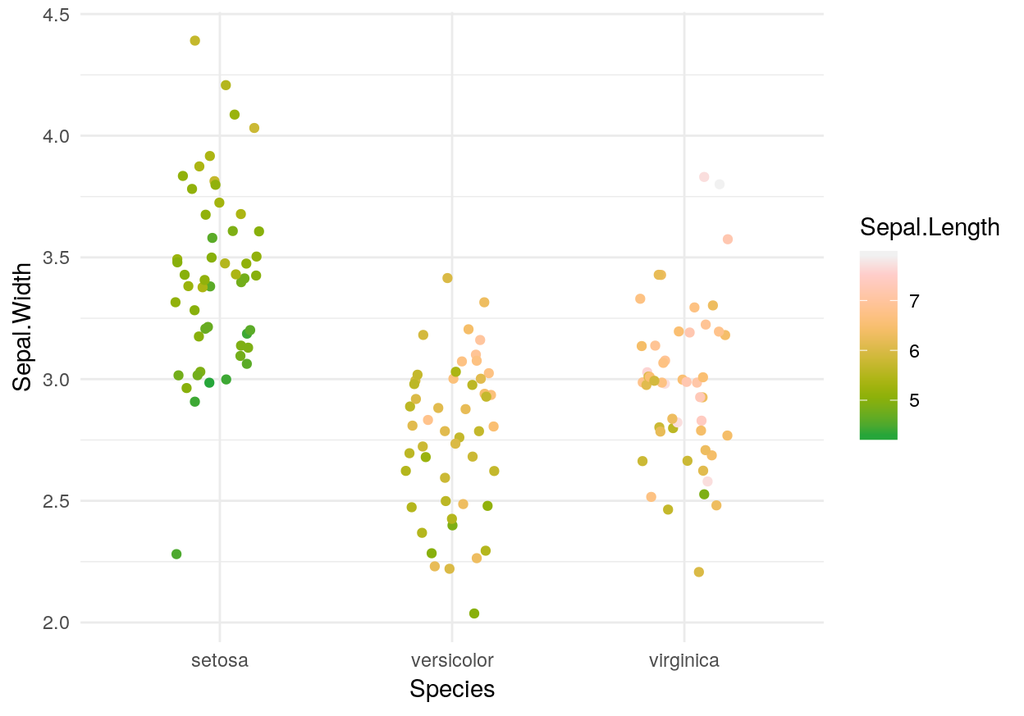

```r
ggplot(iris, aes(x = Species, y = Sepal.Width, color = Sepal.Length)) + geom_jitter(width = 0.2) +
  scale_color_continuous_sequential(palette = "Terrain")
```

Now assume we generally like the color scale but find it a bit too pink at the end. We can fix this issue by specifying an alternative final hue value (`h2=80`):

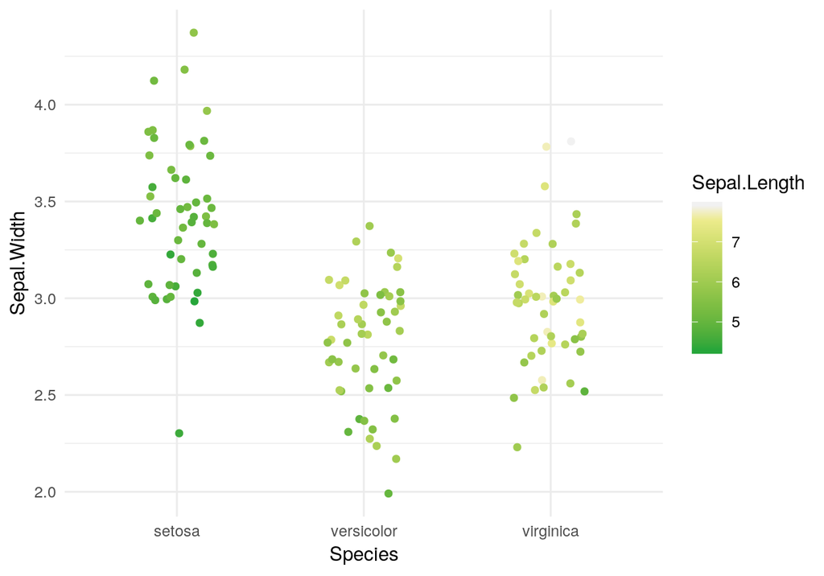

```r
ggplot(iris, aes(x = Species, y = Sepal.Width, color = Sepal.Length)) + geom_jitter(width = 0.2) +
  scale_color_continuous_sequential(palette = "Terrain", h2 = 80)
```

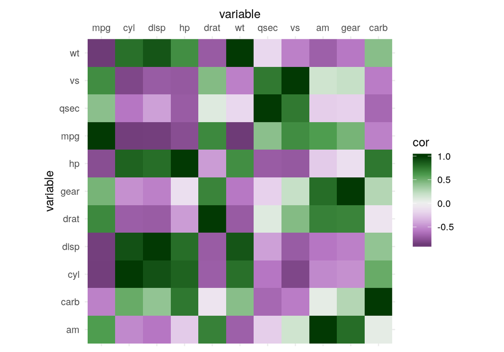

```r
cm <- cor(mtcars)
df_wide <- as.data.frame(cm)
df_long <- stack(df_wide)
names(df_long) <- c("cor", "var1")
df_long <- cbind(df_long, var2 = rep(rownames(cm), length(rownames(cm))))
gg <- ggplot(df_long, aes(var1, var2, fill=cor)) +
  geom_tile() +
  coord_fixed() +
  ylab("variable") +
  scale_x_discrete(position = "top", name = "variable")

gg + scale_fill_continuous_diverging(palette = "Purple-Green")
```

And now the same plot with some palette customizations:

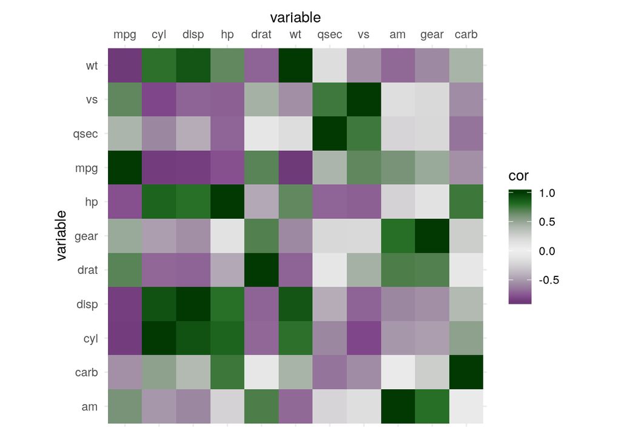

```r
gg + scale_fill_continuous_diverging(palette = "Purple-Green", p1 = 3)
```

See the reference manual for the exact set of customization parameters that are available for each scale.

The continuous scales also provide the option to limit the scale range to which data are mapped, via the parameters `begin` and `end`. As an example, assume we’re using the approximation of the viridis scale provided by `scale_color_continuous_sequential()`:

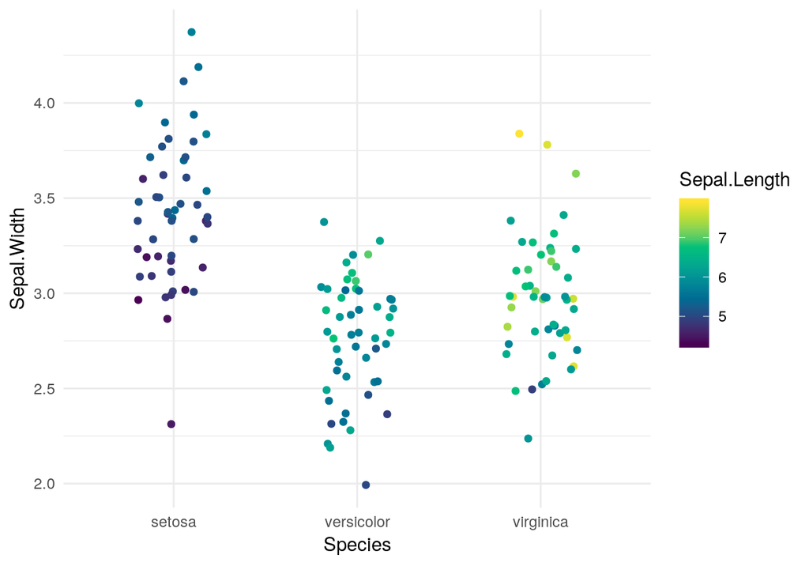

```r
ggplot(iris, aes(x = Species, y = Sepal.Width, color = Sepal.Length)) + geom_jitter(width = 0.2) +
  scale_color_continuous_sequential(palette = "Viridis")
```

If we want to remove some of the darkest blues and some of the brightest yellows from this scale, we can write:

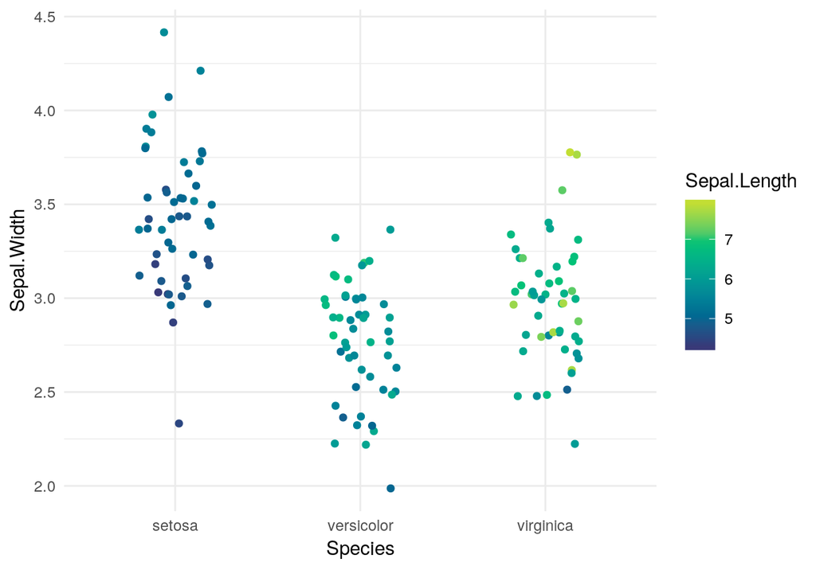

```r
ggplot(iris, aes(x = Species, y = Sepal.Width, color = Sepal.Length)) + geom_jitter(width = 0.2) +
  scale_color_continuous_sequential(palette = "Viridis", begin = 0.15, end = 0.9)
```

Finally, all scales allow easy switching of their direction, via the `rev` argument:

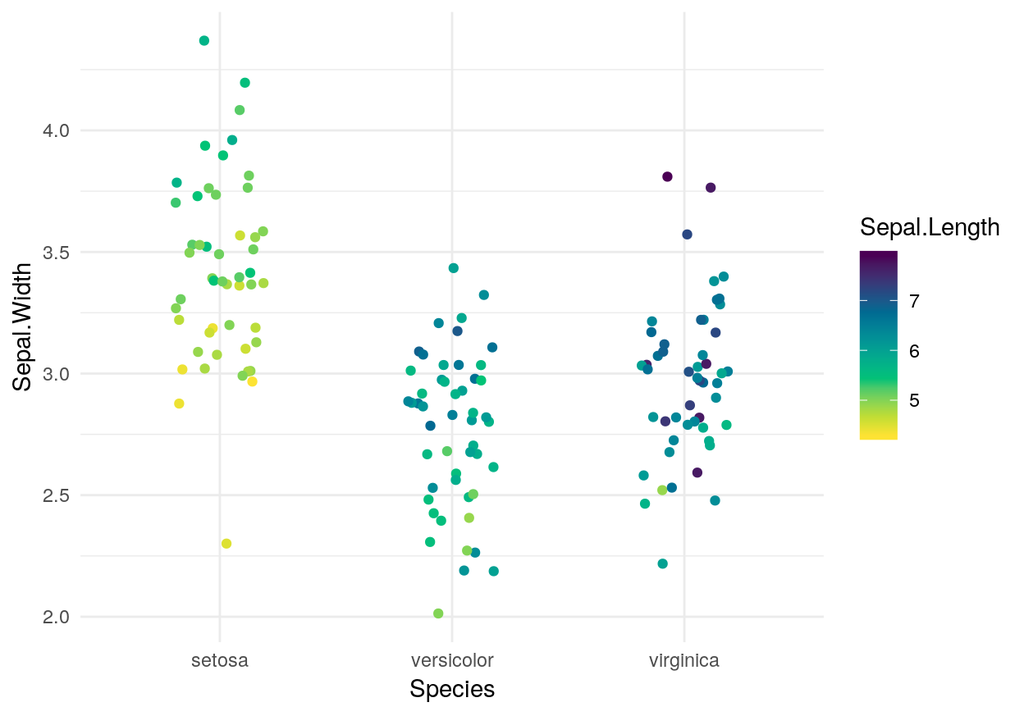

```r
ggplot(iris, aes(x = Species, y = Sepal.Width, color = Sepal.Length)) + geom_jitter(width = 0.2) +
  scale_color_continuous_sequential(palette = "Viridis", rev = TRUE)
```

## Available palettes

In the following, we are visualizing all scales currently available via pre-defined names. These visualizations are generated by the function `hcl_palettes()` with option `plot = TRUE`.

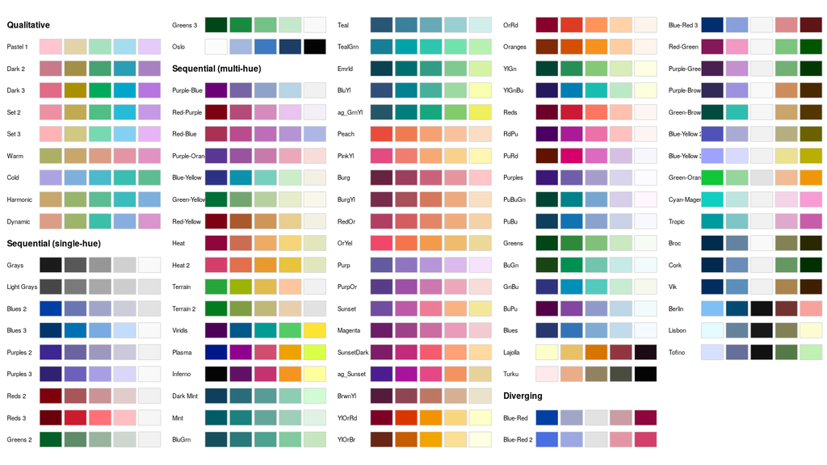

The discrete sequential scales are all called via `scale_*_discrete_sequential(palette = "name")`, where `name` is the name of the palette, e.g. `palette = "Grays"`. Continuous approximations to the discrete scales exist and can be called via `scale_*_continuous_sequential(palette = "name")`

## References

Ihaka, Ross, Paul Murrell, Kurt Hornik, Jason C. Fisher, Reto Stauffer, Claus O. Wilke, Claire D. McWhite, and Achim Zeileis. 2018. **Colorspace**: A Toolbox for Manipulating and Assessing Colors and Palettes. https://CRAN.R-project.org/package=colorspace.

Wickham, Hadley. 2016. **Ggplot2**: Elegant Graphics for Data Analysis. 2nd ed. Springer-Verlag. http://ggplot2.org/.